# Overall Effect Size Calculation & Synthesis

Meta-Analytic Update of Mate-Choice Copying (MCC)

Author

Eduardo Santos & Collaborators

Published

May 26, 2026

## Introduction & Project Update

This protocol implements the overall effect size synthesis for the updated Mate-Choice Copying (MCC) meta-analysis.

Specifically, we integrate: 1. **The New Extractions:** Our newly extracted and verified dataset containing recent trials. 2. **Original Continuous Dataset (Davies et al. 2020):** Standardised mean differences (Hedges’ $d$) analyzing continuous metrics. 3. **Original Binary Dataset (Jones & DuVal 2019):** Log Odds Ratio ($\ln\text{OR}$) analyzing binary choices.

The R script aligns and synthesizes these three sources into unified datasets, allowing comparison of meta-analytic summaries across three key subsets: * **New Extractions Only:** Eduardo’s new dataset. * **Original Only:** Legacy data from the original publications. * **Combined Dataset:** A complete synthesis of old and new trials to estimate the updated global effect sizes.

## Data Loading and Alignment

We read the three datasets, perform data type conversions, extract species epithets for taxonomic control, and align columns into unified Hedges’ $g$ and Odds Ratio datasets.

```r
# ---------------------------------------------------------------------------
# 1. Load Datasets
# ---------------------------------------------------------------------------

# Paths to legacy and new datasets
path_new <- here::here("data", "1_effect_size_calculation_pipeline", "Data Extraction Mate Choice Meta Analysis.xlsx")
path_davies <- here::here("data", "2_original_meta_analyses_datasets", "Davies_et_al_2020_Final_data.xlsx")
path_jones <- here::here("data", "2_original_meta_analyses_datasets", "Jones_DuVal_2019_data.CSV")

# A. Read new extraction dataset (EduardoExtraction sheet)
db_new_raw <- readxl::read_excel(path_new, sheet = "EduardoExtraction")

# B. Read Davies et al. 2020 (Original continuous dataset)
db_davies_raw <- readxl::read_excel(path_davies, sheet = "Data")

# C. Read Jones & DuVal 2019 (Original binary dataset)
db_jones_raw <- readr::read_csv(path_jones)

# ---------------------------------------------------------------------------
# 2. Process and Filter New Extraction
# ---------------------------------------------------------------------------
db_new <- db_new_raw %>%
  filter(is.na(RemoveFromDataset) | RemoveFromDataset != "Yes") %>%
  mutate(
    effectSizeCalculatedHedgesD = as.numeric(effectSizeCalculatedHedgesD),
    effectSizeCalculatedHedgesDVariance = as.numeric(effectSizeCalculatedHedgesDVariance),
    effectSizeCalculatedOddsRatio = as.numeric(effectSizeCalculatedOddsRatio),
    effectSizeCalculatedOddsRatioVariance = as.numeric(effectSizeCalculatedOddsRatioVariance),
    logOddsRatio = log(effectSizeCalculatedOddsRatio),
    logOddsRatioVariance = effectSizeCalculatedOddsRatioVariance
  )

# ---------------------------------------------------------------------------
# 3. Align Datasets for Hedges' g (Continuous SMD Analysis)
# ---------------------------------------------------------------------------

# A. Hedges' g from New Extraction
hedges_new <- db_new %>%
  filter(!is.na(effectSizeCalculatedHedgesD), !is.na(effectSizeCalculatedHedgesDVariance)) %>%
  select(
    yi = effectSizeCalculatedHedgesD,
    vi = effectSizeCalculatedHedgesDVariance,
    identifierStudyId,
    identifierEffectSizeID,
    taxonomySpecies
  ) %>%
  mutate(
    identifierStudyId = as.character(identifierStudyId),
    identifierEffectSizeID = as.character(identifierEffectSizeID),
    # Extract species epithet (last word) and make lowercase for cross-dataset mapping
    taxonomySpecies = str_to_lower(word(as.character(taxonomySpecies), -1)),
    Dataset_Source = "New Extraction (Santos)"
  )

# B. Hedges' g from Davies et al. 2020 (Original)
hedges_davies <- db_davies_raw %>%
  mutate(
    Hedges_d_directional = as.numeric(Hedges_d_directional),
    Variance = as.numeric(Variance)
  ) %>%
  filter(!is.na(Hedges_d_directional), !is.na(Variance), Variance > 0) %>%
  select(
    yi = Hedges_d_directional,
    vi = Variance,
    identifierStudyId = Author,
    identifierEffectSizeID = Effect_size_no,
    taxonomySpecies = Species_latin
  ) %>%
  mutate(
    identifierStudyId = as.character(identifierStudyId),
    identifierEffectSizeID = as.character(identifierEffectSizeID),
    # Extract species epithet (last word) and make lowercase
    taxonomySpecies = str_to_lower(word(as.character(taxonomySpecies), -1)),
    Dataset_Source = "Original (Davies 2020)"
  )

# C. Unified Hedges' g Dataset
db_hedges <- bind_rows(hedges_new, hedges_davies) %>%
  mutate(across(c(identifierStudyId, taxonomySpecies, Dataset_Source), as.factor))

# ---------------------------------------------------------------------------
# 4. Align Datasets for Odds Ratio (Binary Analysis)
# ---------------------------------------------------------------------------

# A. Log Odds Ratio from New Extraction
or_new <- db_new %>%
  filter(!is.na(logOddsRatio), !is.na(logOddsRatioVariance)) %>%
  select(
    yi = logOddsRatio,
    vi = logOddsRatioVariance,
    identifierStudyId,
    identifierEffectSizeID,
    taxonomySpecies
  ) %>%
  mutate(
    identifierStudyId = as.character(identifierStudyId),
    identifierEffectSizeID = as.character(identifierEffectSizeID),
    taxonomySpecies = str_to_lower(word(as.character(taxonomySpecies), -1)),
    Dataset_Source = "New Extraction (Santos)"
  )

# B. Log Odds Ratio from Jones & DuVal 2019 (Original)
or_jones <- db_jones_raw %>%
  filter(!is.na(lnOR), !is.na(VlnOR), VlnOR > 0) %>%
  select(
    yi = lnOR,
    vi = VlnOR,
    identifierStudyId = study,
    identifierEffectSizeID = study_Exp,
    taxonomySpecies = Species
  ) %>%
  mutate(
    identifierStudyId = as.character(identifierStudyId),
    identifierEffectSizeID = as.character(identifierEffectSizeID),
    taxonomySpecies = str_to_lower(as.character(taxonomySpecies)),
    Dataset_Source = "Original (Jones & DuVal 2019)"
  )

# C. Unified Log Odds Ratio Dataset
db_or <- bind_rows(or_new, or_jones) %>%
  mutate(across(c(identifierStudyId, taxonomySpecies, Dataset_Source), as.factor))
```

## Effect Size Distribution (Density Plots)

Before fitting the multi-level models, we inspect the distribution of our aligned effect sizes across the different subsets (New Extraction, Original Only, and Combined).

The density plots below use the same split logic as the orchard plots, facet-wrapping by subset while coloring the distribution curves by their actual dataset source to check for shifts or outliers.

**Hedges’ \(g\) (Continuous SMD)**

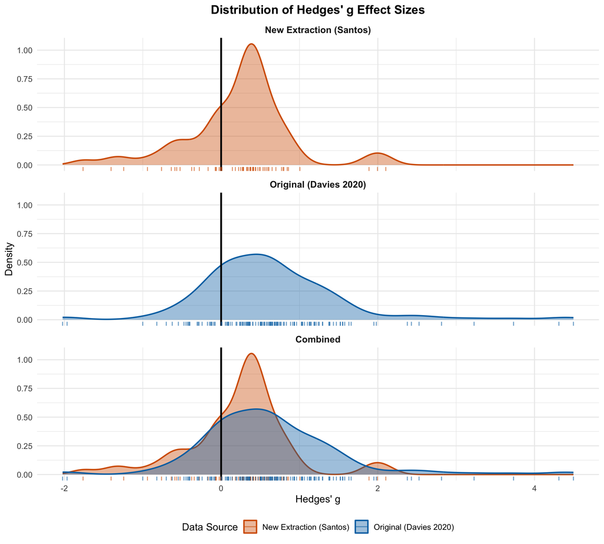

```r
# Prepare density data for Hedges' g
db_hedges_density <- bind_rows(
  db_hedges %>% mutate(Group = as.character(Dataset_Source)),
  db_hedges %>% mutate(Group = "Combined")
) %>%
  mutate(Group = factor(Group, levels = c("New Extraction (Santos)", "Original (Davies 2020)", "Combined")))

# Plot densities
p_hedges_dens <- ggplot(db_hedges_density, aes(x = yi, fill = Dataset_Source, color = Dataset_Source)) +
  geom_density(alpha = 0.4, linewidth = 0.8) +
  geom_vline(xintercept = 0, linewidth = 1.0, linetype = "solid", color = "black") +
  geom_rug(alpha = 0.6) +
  facet_wrap(~ Group, ncol = 1) +
  scale_fill_manual(values = c("New Extraction (Santos)" = "#D55E00", "Original (Davies 2020)" = "#0072B2"), name = "Data Source") +
  scale_color_manual(values = c("New Extraction (Santos)" = "#D55E00", "Original (Davies 2020)" = "#0072B2"), name = "Data Source") +
  labs(
    title = "Distribution of Hedges' g Effect Sizes",
    x = "Hedges' g",
    y = "Density"
  ) +
  theme_minimal(base_size = 12) +
  theme(
    legend.position = "bottom",
    strip.text = element_text(face = "bold", size = 11),
    plot.title = element_text(face = "bold", hjust = 0.5)
  )

print(p_hedges_dens)
```

**Odds Ratio (Binary outcomes)**

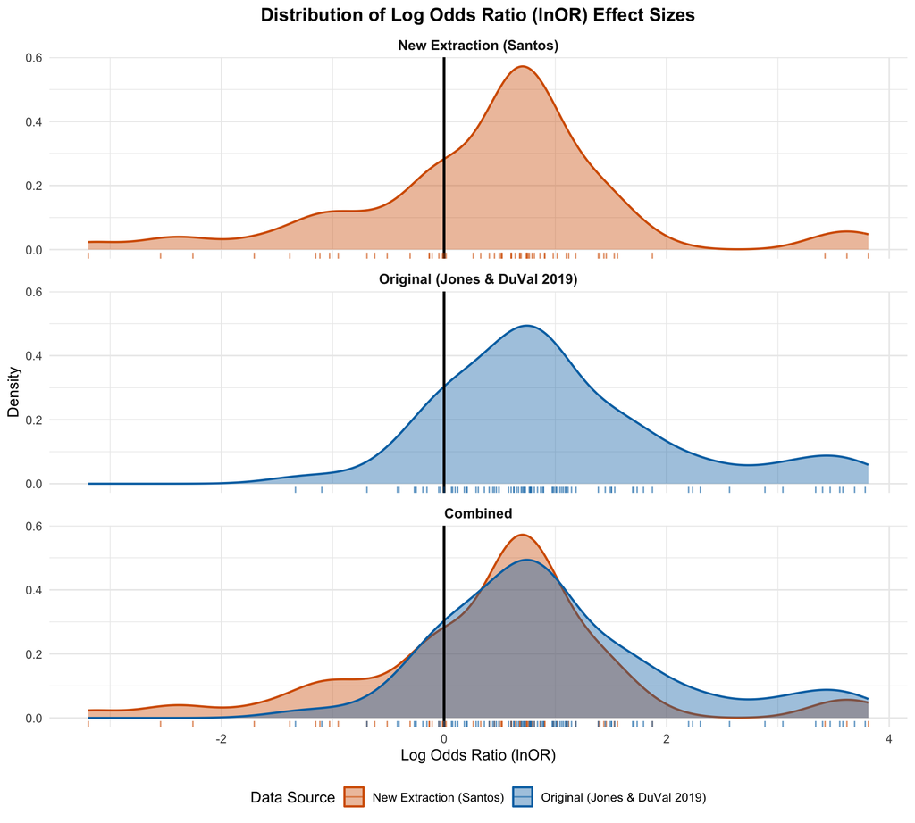

```r
# Prepare density data for Odds Ratio (lnOR)
db_or_density <- bind_rows(
  db_or %>% mutate(Group = as.character(Dataset_Source)),
  db_or %>% mutate(Group = "Combined")
) %>%
  mutate(Group = factor(Group, levels = c("New Extraction (Santos)", "Original (Jones & DuVal 2019)", "Combined")))

# Plot densities
p_or_dens <- ggplot(db_or_density, aes(x = yi, fill = Dataset_Source, color = Dataset_Source)) +
  geom_density(alpha = 0.4, linewidth = 0.8) +
  geom_vline(xintercept = 0, linewidth = 1.0, linetype = "solid", color = "black") +
  geom_rug(alpha = 0.6) +
  facet_wrap(~ Group, ncol = 1) +
  scale_fill_manual(values = c("New Extraction (Santos)" = "#D55E00", "Original (Jones & DuVal 2019)" = "#0072B2"), name = "Data Source") +
  scale_color_manual(values = c("New Extraction (Santos)" = "#D55E00", "Original (Jones & DuVal 2019)" = "#0072B2"), name = "Data Source") +
  labs(
    title = "Distribution of Log Odds Ratio (lnOR) Effect Sizes",
    x = "Log Odds Ratio (lnOR)",
    y = "Density"
  ) +
  theme_minimal(base_size = 12) +
  theme(
    legend.position = "bottom",
    strip.text = element_text(face = "bold", size = 11),
    plot.title = element_text(face = "bold", hjust = 0.5)
  )

print(p_or_dens)
```

## Model Fitting Function

This helper function handles the variance–covariance (VCV) matrix construction and fits a multilevel random-effects model using `rma.mv()` in `metafor`.

- **Variance–Covariance:** We construct a VCV matrix via `vcalc()` to handle dependencies among multiple effect sizes within the same study (assuming $r = 0.5$ for nested measurements).
- **Random intercepts** are modeled for:
  - Study (`identifierStudyId`)
  - Individual trial/effect size (`identifierEffectSizeID`)
  - Species (`taxonomySpecies`) to control for taxonomic/species-level variation

```r
fit_overall_mv <- function(dat, yi = "yi", vi = "vi", cluster_var = "identifierStudyId", obs_var = "identifierEffectSizeID", rho = 0.5) {

  # Remove rows with missing values
  dat2 <- dat %>%
    filter(!is.na(.data[[yi]]), !is.na(.data[[vi]]), .data[[vi]] > 0)

  if (nrow(dat2) == 0) {
    message("No complete cases found.")
    return(NULL)
  }

  # 1. Build VCV Matrix
  VCV <- metafor::vcalc(
    vi = dat2[[vi]],
    cluster = dat2[[cluster_var]],
    obs = dat2[[obs_var]],
    rho = rho,
    data = dat2
  )

  # 2. Fit Multi-Level Random-Effects Model
  mod <- metafor::rma.mv(
    yi = dat2[[yi]],
    V  = VCV,
    random = list(
      ~1 | identifierStudyId,
      ~1 | identifierEffectSizeID,
      ~1 | taxonomySpecies
    ),
    test = "t",
    method = "REML",
    sparse = TRUE,
    data = dat2
  )

  list(data = dat2, VCV = VCV, model = mod)
}
```

## Multi-Level Synthesis Results

We fit the multilevel meta-analysis across all three database splits (New Only, Original Only, and Combined) for both effect size classes.

```r
# ---------------------------------------------------------------------------
# HEDGES' G MODELS
# ---------------------------------------------------------------------------
res_hedges_new   <- fit_overall_mv(db_hedges %>% filter(Dataset_Source == "New Extraction (Santos)"))
res_hedges_orig  <- fit_overall_mv(db_hedges %>% filter(Dataset_Source == "Original (Davies 2020)"))
res_hedges_comb  <- fit_overall_mv(db_hedges)

# ---------------------------------------------------------------------------
# ODDS RATIO MODELS
# ---------------------------------------------------------------------------
res_or_new   <- fit_overall_mv(db_or %>% filter(Dataset_Source == "New Extraction (Santos)"))
res_or_orig  <- fit_overall_mv(db_or %>% filter(Dataset_Source == "Original (Jones & DuVal 2019)"))
res_or_comb  <- fit_overall_mv(db_or)
```

## Results and Visualizations

**Hedges’ \(g\) (Continuous outcomes)**

**Unified Synthesis Plot**

This plot combines all three estimates (New Extraction, Original legacy studies, and the Combined pool) side-by-side in a single panel. Points are colored individually by their true data source.

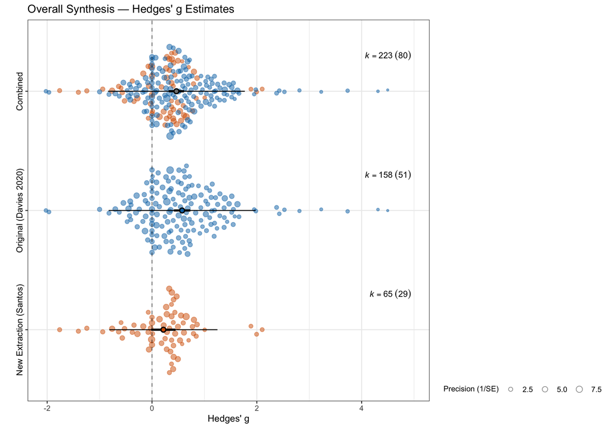

```r
if (!is.null(res_hedges_new) && !is.null(res_hedges_orig) && !is.null(res_hedges_comb)) {
  # 1. Extract S3 result objects using mod_results
  h_new <- orchaRd::mod_results(res_hedges_new$model, group = "identifierStudyId")
  h_orig <- orchaRd::mod_results(res_hedges_orig$model, group = "identifierStudyId")
  h_comb <- orchaRd::mod_results(res_hedges_comb$model, group = "identifierStudyId")

  # 2. Clone S3 result objects to lists for manual editing
  class(h_new) <- "list"
  h_new$mod_table$name <- "New Extraction (Santos)"
  h_new$data$moderator <- "New Extraction (Santos)"
  class(h_new) <- c("orchard", "data.frame")

  class(h_orig) <- "list"
  h_orig$mod_table$name <- "Original (Davies 2020)"
  h_orig$data$moderator <- "Original (Davies 2020)"
  class(h_orig) <- c("orchard", "data.frame")

  class(h_comb) <- "list"
  h_comb$mod_table$name <- "Combined"
  h_comb$data$moderator <- "Combined"
  class(h_comb) <- c("orchard", "data.frame")

  # 3. Merge model results
  sub_hedges <- orchaRd::submerge(h_new, h_orig, h_comb)

  # 4. Add point-level real source mapping
  class(sub_hedges) <- "list"
  sub_hedges$data$real_source <- c(
    rep("New Extraction (Santos)", nrow(h_new$data)),
    rep("Original (Davies 2020)", nrow(h_orig$data)),
    rep("New Extraction (Santos)", nrow(h_new$data)),
    rep("Original (Davies 2020)", nrow(h_orig$data))
  )
  class(sub_hedges) <- c("orchard", "data.frame")

  # 4. Generate Plot
  p_hedges <- orchaRd::orchard_plot(sub_hedges, xlab = "Hedges' g", flip = TRUE)

  # 5. Customize color mapping for points
  p_hedges$layers[[1]]$mapping$colour <- ggplot2::aes(colour = real_source)$colour
  p_hedges$layers[[1]]$mapping$fill <- ggplot2::aes(fill = real_source)$fill

  # 6. Apply themes & custom palette (colorblind friendly orange/blue)
  p_hedges <- p_hedges +
    ggplot2::scale_colour_manual(values = c("New Extraction (Santos)" = "#D55E00", "Original (Davies 2020)" = "#0072B2"), name = "Data Source") +
    ggplot2::scale_fill_manual(values = c("New Extraction (Santos)" = "#D55E00", "Original (Davies 2020)" = "#0072B2"), name = "Data Source") +
    ggplot2::ggtitle("Overall Synthesis — Hedges' g Estimates") +
    ggplot2::theme(legend.position = "right")

  print(p_hedges)
}
```

**Detailed Model Statistics**

Here are the text outputs and fit statistics for the three individual models:

**New Only**

```r
if (!is.null(res_hedges_new)) {
  print(summary(res_hedges_new$model))
  cat("\nHeterogeneity (I^2):\n")
  print(orchaRd::i2_ml(res_hedges_new$model))
}
```

```
Multivariate Meta-Analysis Model (k = 65; method: REML)

  logLik  Deviance       AIC       BIC      AICc
-52.3598  104.7196  112.7196  121.3552  113.3976

Variance Components:

            estim    sqrt  nlvls  fixed                  factor
sigma^2.1  0.0000  0.0000     29     no       identifierStudyId
sigma^2.2  0.1623  0.4029     65     no  identifierEffectSizeID
sigma^2.3  0.0907  0.3011     15     no         taxonomySpecies

Test for Heterogeneity:
Q(df = 64) = 307.8218, p-val < .0001

Model Results:

estimate      se    tval  df    pval    ci.lb   ci.ub
  0.2176  0.1161  1.8739  64  0.0655  -0.0144  0.4496  .

---
Signif. codes:  0 '***' 0.001 '**' 0.01 '*' 0.05 '.' 0.1 ' ' 1


Heterogeneity (I^2):
                 I2_Total      I2_identifierStudyId I2_identifierEffectSizeID
             8.198396e+01              1.228411e-07              5.259971e+01
       I2_taxonomySpecies
             2.938425e+01
```

**Original Only**

```r
if (!is.null(res_hedges_orig)) {
  print(summary(res_hedges_orig$model))
  cat("\nHeterogeneity (I^2):\n")
  print(orchaRd::i2_ml(res_hedges_orig$model))
}
```

```
Multivariate Meta-Analysis Model (k = 158; method: REML)

   logLik   Deviance        AIC        BIC       AICc
-192.8983   385.7966   393.7966   406.0216   394.0598

Variance Components:

            estim    sqrt  nlvls  fixed                  factor
sigma^2.1  0.0147  0.1212     51     no       identifierStudyId
sigma^2.2  0.4731  0.6878    158     no  identifierEffectSizeID
sigma^2.3  0.0092  0.0960     23     no         taxonomySpecies

Test for Heterogeneity:
Q(df = 157) = 1100.4507, p-val < .0001

Model Results:

estimate      se    tval   df    pval   ci.lb   ci.ub
  0.5744  0.0798  7.2003  157  <.0001  0.4168  0.7319  ***

---
Signif. codes:  0 '***' 0.001 '**' 0.01 '*' 0.05 '.' 0.1 ' ' 1


Heterogeneity (I^2):
                 I2_Total      I2_identifierStudyId I2_identifierEffectSizeID
                85.679848                  2.532638                 81.556854
       I2_taxonomySpecies
                 1.590356
```

**Combined**

```r
if (!is.null(res_hedges_comb)) {
  print(summary(res_hedges_comb$model))
  cat("\nHeterogeneity (I^2):\n")
  print(orchaRd::i2_ml(res_hedges_comb$model))
}
```

```
Multivariate Meta-Analysis Model (k = 223; method: REML)

   logLik   Deviance        AIC        BIC       AICc
-256.4733   512.9466   520.9466   534.5573   521.1310

Variance Components:

            estim    sqrt  nlvls  fixed                  factor
sigma^2.1  0.0369  0.1921     80     no       identifierStudyId
sigma^2.2  0.3730  0.6107    223     no  identifierEffectSizeID
sigma^2.3  0.0240  0.1549     31     no         taxonomySpecies

Test for Heterogeneity:
Q(df = 222) = 1420.1063, p-val < .0001

Model Results:

estimate      se    tval   df    pval   ci.lb   ci.ub
  0.4650  0.0739  6.2931  222  <.0001  0.3194  0.6106  ***

---
Signif. codes:  0 '***' 0.001 '**' 0.01 '*' 0.05 '.' 0.1 ' ' 1


Heterogeneity (I^2):
                 I2_Total      I2_identifierStudyId I2_identifierEffectSizeID
                85.705671                  7.288207                 73.675938
       I2_taxonomySpecies
                 4.741526
```

**Odds Ratio (Binary outcomes)**

**Unified Synthesis Plot**

This plot combines all three estimates (New Extraction, Original legacy studies, and the Combined pool) side-by-side in a single panel. Points are colored individually by their true data source.

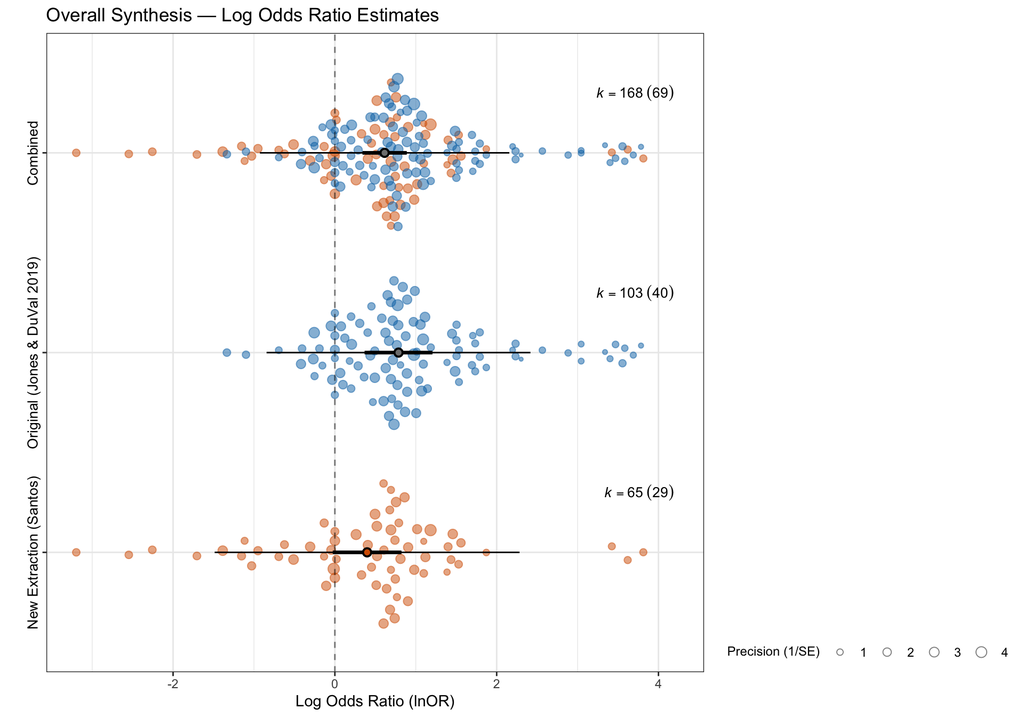

```r
if (!is.null(res_or_new) && !is.null(res_or_orig) && !is.null(res_or_comb)) {
  # 1. Extract S3 result objects using mod_results
  o_new <- orchaRd::mod_results(res_or_new$model, group = "identifierStudyId")
  o_orig <- orchaRd::mod_results(res_or_orig$model, group = "identifierStudyId")
  o_comb <- orchaRd::mod_results(res_or_comb$model, group = "identifierStudyId")

  # 2. Clone S3 result objects to lists for manual editing
  class(o_new) <- "list"
  o_new$mod_table$name <- "New Extraction (Santos)"
  o_new$data$moderator <- "New Extraction (Santos)"
  class(o_new) <- c("orchard", "data.frame")

  class(o_orig) <- "list"
  o_orig$mod_table$name <- "Original (Jones & DuVal 2019)"
  o_orig$data$moderator <- "Original (Jones & DuVal 2019)"
  class(o_orig) <- c("orchard", "data.frame")

  class(o_comb) <- "list"
  o_comb$mod_table$name <- "Combined"
  o_comb$data$moderator <- "Combined"
  class(o_comb) <- c("orchard", "data.frame")

  # 3. Merge model results
  sub_or <- orchaRd::submerge(o_new, o_orig, o_comb)

  # 4. Add point-level real source mapping
  class(sub_or) <- "list"
  sub_or$data$real_source <- c(
    rep("New Extraction (Santos)", nrow(o_new$data)),
    rep("Original (Jones & DuVal)", nrow(o_orig$data)),
    rep("New Extraction (Santos)", nrow(o_new$data)),
    rep("Original (Jones & DuVal)", nrow(o_orig$data))
  )
  class(sub_or) <- c("orchard", "data.frame")

  # 4. Generate Plot
  p_or <- orchaRd::orchard_plot(sub_or, xlab = "Log Odds Ratio (lnOR)", flip = TRUE)

  # 5. Customize color mapping for points
  p_or$layers[[1]]$mapping$colour <- ggplot2::aes(colour = real_source)$colour
  p_or$layers[[1]]$mapping$fill <- ggplot2::aes(fill = real_source)$fill

  # 6. Apply themes & custom palette (colorblind friendly orange/blue)
  p_or <- p_or +
    ggplot2::scale_colour_manual(values = c("New Extraction (Santos)" = "#D55E00", "Original (Jones & DuVal)" = "#0072B2"), name = "Data Source") +
    ggplot2::scale_fill_manual(values = c("New Extraction (Santos)" = "#D55E00", "Original (Jones & DuVal)" = "#0072B2"), name = "Data Source") +
    ggplot2::ggtitle("Overall Synthesis — Log Odds Ratio Estimates") +
    ggplot2::theme(legend.position = "right")

  print(p_or)
}
```

**Detailed Model Statistics**

Here are the text outputs and fit statistics for the three individual models:

**New Only**

```r
if (!is.null(res_or_new)) {
  print(summary(res_or_new$model))
  cat("\nHeterogeneity (I^2):\n")
  print(orchaRd::i2_ml(res_or_new$model))
}
```

```
Multivariate Meta-Analysis Model (k = 65; method: REML)

  logLik  Deviance       AIC       BIC      AICc
-90.9146  181.8291  189.8291  198.4646  190.5071

Variance Components:

            estim    sqrt  nlvls  fixed                  factor
sigma^2.1  0.0000  0.0000     29     no       identifierStudyId
sigma^2.2  0.5411  0.7356     65     no  identifierEffectSizeID
sigma^2.3  0.3033  0.5508     15     no         taxonomySpecies

Test for Heterogeneity:
Q(df = 64) = 307.9156, p-val < .0001

Model Results:

estimate      se    tval  df    pval    ci.lb   ci.ub
  0.3986  0.2126  1.8752  64  0.0653  -0.0261  0.8233  .

---
Signif. codes:  0 '***' 0.001 '**' 0.01 '*' 0.05 '.' 0.1 ' ' 1


Heterogeneity (I^2):
                 I2_Total      I2_identifierStudyId I2_identifierEffectSizeID
             8.198314e+01              2.250186e-07              5.253372e+01
       I2_taxonomySpecies
             2.944942e+01
```

**Original Only**

```r
if (!is.null(res_or_orig)) {
  print(summary(res_or_orig$model))
  cat("\nHeterogeneity (I^2):\n")
  print(orchaRd::i2_ml(res_or_orig$model))
}
```

```
Multivariate Meta-Analysis Model (k = 103; method: REML)

   logLik   Deviance        AIC        BIC       AICc
-124.6888   249.3775   257.3775   267.8774   257.7899

Variance Components:

            estim    sqrt  nlvls  fixed                  factor
sigma^2.1  0.0000  0.0000     40     no       identifierStudyId
sigma^2.2  0.1976  0.4445    103     no  identifierEffectSizeID
sigma^2.3  0.4337  0.6586     17     no         taxonomySpecies

Test for Heterogeneity:
Q(df = 102) = 287.4819, p-val < .0001

Model Results:

estimate      se    tval   df    pval   ci.lb   ci.ub
  0.7867  0.2116  3.7178  102  0.0003  0.3670  1.2065  ***

---
Signif. codes:  0 '***' 0.001 '**' 0.01 '*' 0.05 '.' 0.1 ' ' 1


Heterogeneity (I^2):
                 I2_Total      I2_identifierStudyId I2_identifierEffectSizeID
             7.548085e+01              1.182344e-07              2.362511e+01
       I2_taxonomySpecies
             5.185574e+01
```

**Combined**

```r
if (!is.null(res_or_comb)) {
  print(summary(res_or_comb$model))
  cat("\nHeterogeneity (I^2):\n")
  print(orchaRd::i2_ml(res_or_comb$model))
}
```

```
Multivariate Meta-Analysis Model (k = 168; method: REML)

   logLik   Deviance        AIC        BIC       AICc
-225.7641   451.5281   459.5281   472.0001   459.7751

Variance Components:

            estim    sqrt  nlvls  fixed                  factor
sigma^2.1  0.0359  0.1894     69     no       identifierStudyId
sigma^2.2  0.3654  0.6045    168     no  identifierEffectSizeID
sigma^2.3  0.1891  0.4349     29     no         taxonomySpecies

Test for Heterogeneity:
Q(df = 167) = 605.4002, p-val < .0001

Model Results:

estimate      se    tval   df    pval   ci.lb   ci.ub
  0.6147  0.1388  4.4297  167  <.0001  0.3407  0.8887  ***

---
Signif. codes:  0 '***' 0.001 '**' 0.01 '*' 0.05 '.' 0.1 ' ' 1


Heterogeneity (I^2):
                 I2_Total      I2_identifierStudyId I2_identifierEffectSizeID
                75.047959                  4.559692                 46.451236
       I2_taxonomySpecies
                24.037031
```

## Sensitivity Analysis: Impact of the VCV Structure

To evaluate the robustness of our meta-analytic results, we conduct a sensitivity analysis comparing the main multilevel models (which incorporate a Variance-Covariance [VCV] matrix with an assumed within-study correlation $\rho = 0.5$) against simplified multilevel models that ignore this correlation (i.e., treating effect size variances as independent diagonal elements, $V = v_i$).

Ignoring within-study correlation can lead to improper weighting of studies with multiple effect sizes and can bias the standard errors and confidence intervals of the pooled estimates.

```r
# 1. Define comparison function
compare_vcv_models <- function(dat, name, yi = "yi", vi = "vi", cluster_var = "identifierStudyId", obs_var = "identifierEffectSizeID", rho = 0.5) {
  dat2 <- dat %>%
    filter(!is.na(.data[[yi]]), !is.na(.data[[vi]]), .data[[vi]] > 0)

  if (nrow(dat2) == 0) return(NULL)

  # A. With VCV (rho = 0.5)
  VCV <- metafor::vcalc(
    vi = dat2[[vi]],
    cluster = dat2[[cluster_var]],
    obs = dat2[[obs_var]],
    rho = rho,
    data = dat2
  )
  mod_w_vcv <- metafor::rma.mv(
    yi = dat2[[yi]],
    V  = VCV,
    random = list(
      ~1 | identifierStudyId,
      ~1 | identifierEffectSizeID,
      ~1 | taxonomySpecies
    ),
    test = "t",
    method = "REML",
    sparse = TRUE,
    data = dat2
  )

  # B. Without VCV (diagonal V = vi)
  mod_no_vcv <- metafor::rma.mv(
    yi = dat2[[yi]],
    V  = dat2[[vi]],
    random = list(
      ~1 | identifierStudyId,
      ~1 | identifierEffectSizeID,
      ~1 | taxonomySpecies
    ),
    test = "t",
    method = "REML",
    sparse = TRUE,
    data = dat2
  )

  # Combine results
  data.frame(
    Analysis = name,
    Model_Type = c("With VCV (rho = 0.5)", "Without VCV (Independent)"),
    k = c(mod_w_vcv$k, mod_no_vcv$k),
    Estimate = c(mod_w_vcv$b[1], mod_no_vcv$b[1]),
    SE = c(mod_w_vcv$se[1], mod_no_vcv$se[1]),
    CI_Lower = c(mod_w_vcv$ci.lb[1], mod_no_vcv$ci.lb[1]),
    CI_Upper = c(mod_w_vcv$ci.ub[1], mod_no_vcv$ci.ub[1]),
    p_val = c(mod_w_vcv$pval[1], mod_no_vcv$pval[1])
  )
}

# 2. Run comparisons across all subsets
comp_hedges_new  <- compare_vcv_models(db_hedges %>% filter(Dataset_Source == "New Extraction (Santos)"), "Hedges' g (New Only)")
comp_hedges_orig <- compare_vcv_models(db_hedges %>% filter(Dataset_Source == "Original (Davies 2020)"), "Hedges' g (Original Only)")
comp_hedges_comb <- compare_vcv_models(db_hedges, "Hedges' g (Combined)")

comp_or_new  <- compare_vcv_models(db_or %>% filter(Dataset_Source == "New Extraction (Santos)"), "Log OR (New Only)")
comp_or_orig <- compare_vcv_models(db_or %>% filter(Dataset_Source == "Original (Jones & DuVal 2019)"), "Log OR (Original Only)")
comp_or_comb <- compare_vcv_models(db_or, "Log OR (Combined)")

# 3. Bind all comparisons together
vcv_comparison_results <- bind_rows(
  comp_hedges_new, comp_hedges_orig, comp_hedges_comb,
  comp_or_new, comp_or_orig, comp_or_comb
)
```

### Sensitivity Comparison Table

The interactive table below compares the pool estimate, standard error (SE), 95% Confidence Intervals, and p-values for both models across all subsets.

| Analysis | Model_Type | k | Estimate | SE | CI_Lower | CI_Upper | p_val |
| --- | --- | --- | --- | --- | --- | --- | --- |
| Hedges' g (New Only) | With VCV (rho = 0.5) | 65 | 0.217611642013285 | 0.1161289135455465 | -0.01438253230034892 | 0.4496058163269189 | 0.06551348957558033 |
| Hedges' g (New Only) | Without VCV (Independent) | 65 | 0.2258130015712826 | 0.1228912507018909 | -0.01969049421207489 | 0.4713164973546402 | 0.0707785902128694 |
| Hedges' g (Original Only) | With VCV (rho = 0.5) | 158 | 0.5743543337199644 | 0.07976799927110266 | 0.4167974459993813 | 0.7319112214405474 | 2.344031235474641e-11 |
| Hedges' g (Original Only) | Without VCV (Independent) | 158 | 0.6041232834627593 | 0.08032839140639095 | 0.4454595152694815 | 0.7627870516560372 | 3.93782959556841e-12 |
| Hedges' g (Combined) | With VCV (rho = 0.5) | 223 | 0.4649638315992444 | 0.0738852567984945 | 0.3193576096213051 | 0.6105700535771837 | 1.640197740409104e-09 |
| Hedges' g (Combined) | Without VCV (Independent) | 223 | 0.4853451273873433 | 0.07521363173024916 | 0.3371210671076369 | 0.6335691876670497 | 6.795266202041284e-10 |
| Log OR (New Only) | With VCV (rho = 0.5) | 65 | 0.3986036851543656 | 0.2125711748893111 | -0.02605605457516386 | 0.823263424883895 | 0.06533524571880747 |
| Log OR (New Only) | Without VCV (Independent) | 65 | 0.4140197954615707 | 0.2245468597345334 | -0.03456412501402217 | 0.8626037159371637 | 0.06984230511453622 |
| Log OR (Original Only) | With VCV (rho = 0.5) | 103 | 0.786727529788425 | 0.2116093942215533 | 0.3670012996826109 | 1.206453759894239 | 0.0003286094593647126 |
| Log OR (Original Only) | Without VCV (Independent) | 103 | 0.8009438006200142 | 0.2097838693709813 | 0.3848384903996984 | 1.21704911084033 | 0.0002311858930162908 |

[output cut: 2 more lines]